# Lab 06 — Hypothesis Testing from Claims

EAES 480 — Modern Statistics in Earth & Environmental Science

March 29, 2026

# Overview

This lab introduces **hypothesis testing** as an extension of sampling, bootstrap distributions, and uncertainty quantification.

The core idea is simple:

> A **claim** about the population becomes a **null hypothesis**.

You will use the **US-AMS simplified AmeriFlux dataset** again and test claims about population means using:

- one sample,
- a bootstrap estimate of uncertainty,
- a z-statistic,
- and a p-value.

This lab emphasizes **reasoning from claims to tests**, not just mechanics.

# Learning goals

By the end of this lab, you should be able to:

- Turn a verbal claim into a null hypothesis
- Choose a variable and define the relevant population parameter
- Draw a sample and estimate a mean
- Use bootstrap resampling to estimate uncertainty in that mean
- Compute a z-statistic and p-value
- Interpret a hypothesis test in plain language
- Connect confidence intervals and hypothesis tests

# Data

## Load and inspect

```r
# GOAL: Read the dataset and clean the names.

df <- read_csv("data/us-ams-simple.csv", na = c("-9999")) %>%
  clean_names() %>%
  filter(year_local == 2023)

glimpse(df)
```

```
## Rows: 16,973
## Columns: 10
## $ year_local <dbl> 2023, 2023, 2023, 2023, 2023, 2023, 2023, 2023, 2023, 2023,…
## $ doy        <dbl> 1.0000, 1.0208, 1.0416, 1.0624, 1.0833, 1.1041, 1.1249, 1.1…
## $ daytime    <dbl> 0, 0, 0, 0, 0, 0, 0, 0, NA, NA, 0, 0, 0, 0, 0, 0, 1, 1, 1, …
## $ fc         <dbl> 1.4444700, 1.0018700, 1.7665700, 0.4639850, 0.8243290, 0.64…
## $ le         <dbl> -2.975490, -1.814240, -5.101540, -4.854642, -2.419090, -10.…
## $ ta         <dbl> 7.433350, 7.783740, 8.273390, 8.702240, 8.896600, 8.567610,…
## $ reco       <dbl> 1.291612, 1.312279, 1.341193, 1.366625, 1.378268, 1.359013,…
## $ gpp        <dbl> -0.1528577, 0.3104090, -0.4253767, 0.9026402, 0.5539394, 0.…
## $ swc        <dbl> 36.13111, 36.11948, 36.11560, 36.11172, 36.11172, 36.10008,…
## $ ts         <dbl> 2.50, 2.50, 2.50, 2.50, 2.50, 2.50, 2.50, 2.50, 2.50, 2.50,…
```

## Derive time columns (if needed)

```r
# GOAL: Create date / month / day_night columns as in earlier labs.

df <- df %>%
  mutate(
    date = as.Date(floor(doy) - 1, origin = paste0(year_local, "-01-01")),
    month = month(date, label = TRUE, abbr = TRUE),
    day_night = if_else(daytime == 1, "Day", "Night")
  )
```

# Part I — From claim to hypothesis test

## 1) Choose a variable

Choose **one numeric variable** from the dataset.

Possible examples: - `swc` - `ta` - `fc` - `gpp` - `le`

```r
target_var <- "gpp"

# CHECK: does this variable exist?
target_var %in% names(df)
```

```
## [1] TRUE
```

## 2) Describe the population parameter

Write the population parameter you care about:

> $\mu$ = the true 2023 population mean of `gpp`

Fill in the blank in words:

> In this lab, my population parameter is the true annual mean of **`gpp`** at the US-AMS site.

## 3) Make a claim

Write a claim about the population mean for your variable.

Examples: - “The annual mean soil water content is 0.30.” - “The annual mean air temperature is 10 °C.” - “The annual mean latent heat flux is 40 W m$^{-2}$.”

Now turn your claim into hypotheses:

- Null hypothesis: $H_0: \mu = \mu_0$
- Alternative hypothesis: $H_A: \mu \neq \mu_0$

Fill these in:

> My claim is: `The annual mean GPP is 5.5 µmolCO2 m-2 s-1`

> $H_0$: `The annual mean GPP is 0, and there is no correlation between GPP and time.`

> $H_A$: `The annual mean GPP is 5.5 µmolCO2 m-2 s-1`

## 4) Draw one sample and compute the sample mean

```r
# GOAL: Draw one random sample and compute its mean.

set.seed(111)

n_samp <- 250   # e.g., 200

samp <- df %>%
  filter(!is.na(.data[[target_var]])) %>%
  slice_sample(n = n_samp)

sample_mean <- mean(samp[[target_var]], na.rm = TRUE)

sample_mean
```

```
## [1] 5.728121
```

**Prompt (2–3 sentences):** How does your sample mean compare to your claim? Is it close, or already quite different?

## 5) Bootstrap the sample mean

```r
# GOAL: Bootstrap the sample mean to estimate uncertainty.

set.seed(111)

B <- 1500   # e.g., 4000

boot_means <- replicate(
  B,
  mean(sample(samp[[target_var]], size = n_samp, replace = TRUE), na.rm = TRUE)
)

head(boot_means)
```

```
## [1] 5.446040 4.335619 5.199671 6.125626 5.357193 4.312086
```

## 6) Estimate uncertainty

```r
# GOAL: Compute the bootstrap SE and 95% CI.

boot_se <- sd(boot_means)
boot_ci <- quantile(boot_means, probs = c(0.025, 0.975))

tibble(
  sample_mean = sample_mean,
  boot_se = boot_se,
  ci_lower = boot_ci[1],
  ci_upper = boot_ci[2]
)
```

| sample_mean | boot_se | ci_lower | ci_upper |
| --- | --- | --- | --- |
| 5.728121 | 0.64014 | 4.53167 | 7.039513 |

**Prompt (2–3 sentences):** What does the bootstrap SE tell you? What does the 95% CI tell you?

> *The bootstrap SE tells me that the bootstrapped sample mean had a standard error of +- 0.64 µmolCO2 m-2 s-1, and that my alternate hypothesis of 5.5 µmolCO2 m-2 s-1 is within this this standard error measurement. The 95% confidence intervals give us the specific quantitative value of the sample mean according to the standard error within 95% confidence.*

## 7) Convert the claim into a formal test

Define the null value from your claim.

```r
# GOAL: Compute z and p-value for your claim.

mu0 <- 0.1   # numeric claim value

z_stat <- (sample_mean - mu0) / boot_se

p_value <- 2 * pnorm(-abs(z_stat))

tibble(
  sample_mean = sample_mean,
  mu0 = mu0,
  boot_se = boot_se,
  z_stat = z_stat,
  p_value = p_value
)
```

| sample_mean | mu0 | boot_se | z_stat | p_value |
| --- | --- | --- | --- | --- |
| 5.728121 | 0.1 | 0.64014 | 8.792015 | 1.469008e-18 |

## 8) Interpret the result

Use your p-value and CI to answer:

- Does the 95% CI include the null value?
- Is the p-value small or large?
- Would you reject the null hypothesis at $\alpha = 0.05$?

Fill in:

> My p-value is `1.469008e-18`, which is very small.

> Therefore, I would reject $H_0$ at the 0.05 level.

**Prompt (4–6 sentences):** Explain your decision in plain language. Do the data make the claim look plausible or surprising? Be careful: “fail to reject” does not mean “prove true.”

> *The p-value that is interpreting if 0 is plausible against the true mean of the population is found to be 1.469008e-18, which is extremely low. This reveals that we can reject the null hypothesis, which is that the mean GPP over the year is 0. This makes plausible sense because you would expect at least some amount of GPP over a given year. It also makes sense because the true mean of the population is 5.7 with a standard error of only .64, this puts a value of 0 highly outside this range, so we can reject the null hypothesis.*

## 9) Visualize the hypothesis test

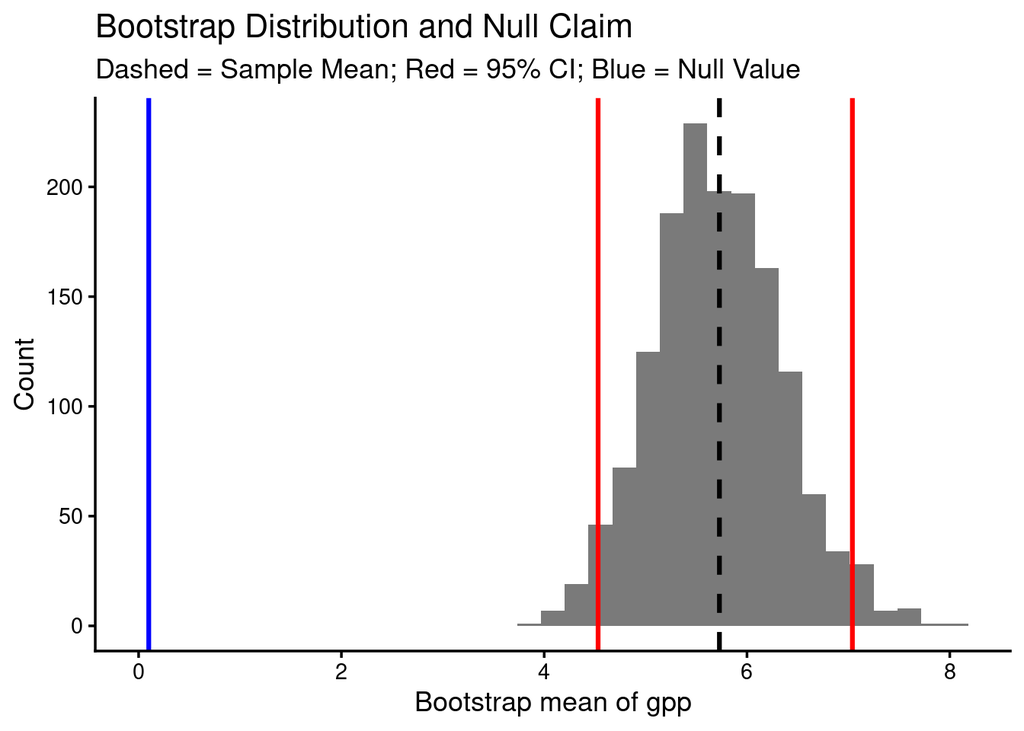

```r
# GOAL: Plot the bootstrap distribution, sample mean, CI, and null value.

ggplot(tibble(boot_mean = boot_means), aes(x = boot_mean)) +
  geom_histogram(bins = 35, alpha = 0.8) +
  geom_vline(xintercept = sample_mean, linetype = "dashed", linewidth = 1.1) +
  geom_vline(xintercept = boot_ci, color = "red", linewidth = 1.1) +
  geom_vline(xintercept = mu0, color = "blue", linewidth = 1.1) +
  theme_classic(base_size = 13.5) +
  labs(
    x = paste0("Bootstrap mean of ", target_var),
    y = "Count",
    title = "Bootstrap Distribution and Null Claim",
    subtitle = "Dashed = Sample Mean; Red = 95% CI; Blue = Null Value"
  )
```

**Prompt (2–3 sentences):** Does the plot agree with your p-value-based conclusion? Explain.

> *Yes, the plot agrees with the p-value based conclusion because the blue line displaying the null hypothesis is extremely outside of the bootstrap distirbution range. This aligns with the small p-value of 1.469008e-18.*

## 10) Try a second claim (short extension)

Keep the same variable, but test a **different null value**.

```r
# GOAL: Test a second claim using the same sample and bootstrap SE.

mu0_alt <- 10

z_stat_alt <- (sample_mean - mu0_alt) / boot_se
p_value_alt <- 2 * pnorm(-abs(z_stat_alt))

tibble(
  mu0_alt = mu0_alt,
  z_stat_alt = z_stat_alt,
  p_value_alt = p_value_alt
)
```

| mu0_alt | z_stat_alt | p_value_alt |
| --- | --- | --- |
| 10 | -6.673351 | 2.500276e-11 |

**Prompt (3–4 sentences):** How did changing the null value change the conclusion? What does this tell you about the relationship between the null hypothesis and the observed estimate?

# Part II — Comparing group means with t-tests

In Part I, you tested a claim about **one population mean**.

Now you will extend the same logic to compare **two group means**.

The key idea is:

> A two-sample t-test asks whether the difference between two group means is large relative to the uncertainty in that difference.

You will first work with a built-in grouping variable (**day vs night**), then choose a second grouping variable of your own.

## 11) Create a day/night grouping variable

If you already created `day_night` earlier, you can reuse it. Otherwise, create it here.

```r
# GOAL: create a day/night grouping variable from `daytime`.

df <- df %>%
  mutate(
    day_night = if_else(daytime == 1, "Day", "Night")
  )

df %>% count(day_night)
```

| day_night | n |
| --- | --- |
| Day | 8287 |
| Night | 7767 |
| NA | 919 |

## 12) Choose a response variable for the t-test

Pick one numeric response variable to compare between groups.

Possible examples: - `ta` - `swc` - `fc` - `gpp` - `le`

```r
response_var <- "gpp"

# CHECK: does this variable exist?
response_var %in% names(df)
```

```
## [1] TRUE
```

## 13) Visualize the response by day/night

Create a plot that shows how your response variable differs between Day and Night.

You may use: - `geom_boxplot()` - `geom_violin()` - `geom_jitter()` - or a combination

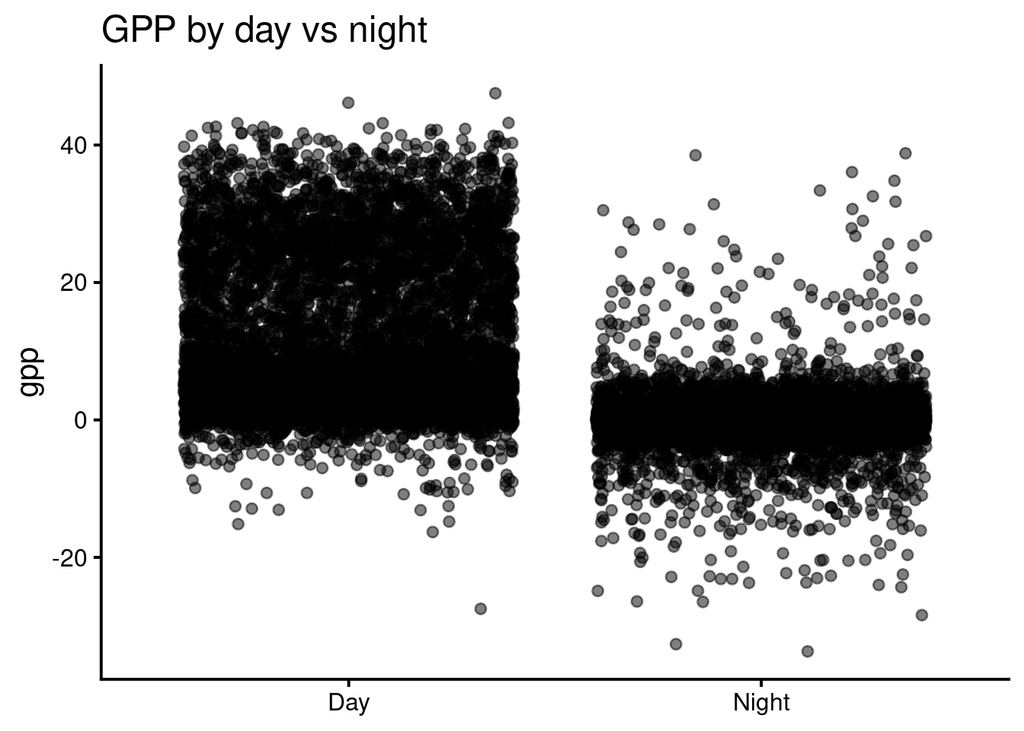

```r
# GOAL: visualize the response by day/night group.
df <- df %>%
  filter(!is.na(day_night)) %>%
  droplevels()

df %>%
  filter(!is.na(.data[[response_var]])) %>%
  ggplot(aes(x = day_night, y = gpp)) +
  geom_jitter(alpha = 0.5) +
  theme_classic(base_size = 15) +
  labs(
    x = NULL,
    y = response_var,
    title = "GPP by day vs night"
  )
```

**Prompt (2–3 sentences):** Before running the test, what do you predict?  
Do the groups look different in center? In spread?

> *I predict that the GPP at night will be close to 0 since there is no light for photosynthesis to occur. I think this would display a center at 0 and a narrow spread, while the Daytime GPP would display a larger range with more positive values, possibly a center around 10 since the mean over day and night is 5.*

## 14) Summarize the two groups

Compute the group means, SDs, and sample sizes.

```r
# GOAL: summarize the response variable by day/night group.

group_summary <- df %>%
  filter(!is.na(.data[[response_var]])) %>%
  group_by(day_night) %>%
  summarise(
    mean_response = mean(gpp),
    sd_response = sd(gpp),
    n = n(),
    .groups = "drop"
  )

group_summary
```

| day_night | mean_response | sd_response | n |
| --- | --- | --- | --- |
| Day | 11.19553979 | 11.266179 | 8287 |
| Night | 0.02642738 | 4.051988 | 7767 |

## 15) State the hypotheses for the day/night comparison

Write hypotheses in words and symbols.

Use this structure:

- Null: the two group means are equal
- Alternative: the two group means are different

Fill in:

> My response variable is `gpp`

> $H_0$: `The GPP is the same whether it is day or night.`

> $H_A$: `The GPP is higher in the day than it is at night.`

## 16) Run a two-sample t-test

Use `t.test()` to compare the means of your response variable between Day and Night.

```r
# GOAL: run a two-sample t-test by formula.

t.test(
  gpp ~ day_night,
  data = df
)
```

```
##
##  Welch Two Sample t-test
##
## data:  gpp by day_night
## t = 84.599, df = 10517, p-value < 2.2e-16
## alternative hypothesis: true difference in means between group Day and group Night is not equal to 0
## 95 percent confidence interval:
##  10.91032 11.42790
## sample estimates:
##   mean in group Day mean in group Night
##         11.19553979          0.02642738
```

**Prompt (4–6 sentences):** Report the p-value and confidence interval.  
Would you reject the null hypothesis at $\alpha = 0.05$?  
What does the result imply about day vs night differences in your chosen variable?

> *The p-value is < 2.2E-16 (basically 0), and the confidence interval is 95%. I would reject the null hypothesis that the GPP is the same whether it is day or night, because the p-value comparing day and night is extremely low, proving extremely dissimilar results in a 95% confidence interval. The result implies that GPP is very different during the day vs during the night.*

## 17) Connect the t-test to a confidence interval

Extract the confidence interval and interpret it as a difference in means.

```r
# GOAL: store the t-test result in an object.

tt_daynight <- t.test(
  gpp ~ day_night,
  data = df
)

tt_daynight$conf.int
```

```
## [1] 10.91032 11.42790
## attr(,"conf.level")
## [1] 0.95
```

**Prompt (2–3 sentences):** Does the confidence interval include 0?  
How does that connect to the hypothesis test decision?

> *The confidence interval does not include the value 0. This connects to the hypothesis test conclusion because if the confidence included 0, you could fail to reject the null hypothesis. This would be because the null hypothesis is 0.*

## 18) Bootstrap view of the same comparison (conceptual extension)

Create bootstrap distributions of the **group means** for Day and Night separately.

```r
set.seed(501)

B <- 501   # e.g., 2000

x_day <- df %>%
  filter(day_night == "Day") %>%
  pull(gpp) %>%
  na.omit()

x_night <- df %>%
  filter(day_night == "Night") %>%
  pull(gpp) %>%
  na.omit()

boot_day <- replicate(
  B,
  mean(sample(x_day, size = length(x_day), replace = TRUE))
)

boot_night <- replicate(
  B,
  mean(sample(x_night, size = length(x_night), replace = TRUE))
)

boot_groups <- bind_rows(
  tibble(group = "Day", mean_est = boot_day),
  tibble(group = "Night", mean_est = boot_night)
)
```

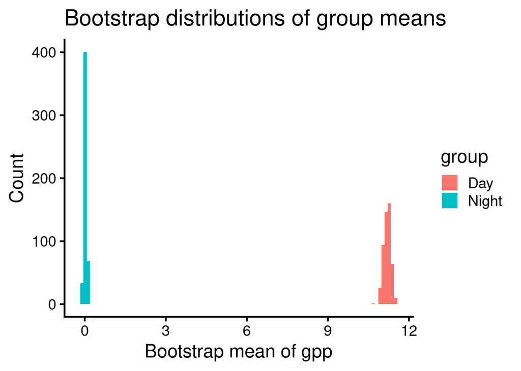

```r
# GOAL: visualize the bootstrap distributions by group.

ggplot(boot_groups, aes(x = mean_est, fill = group)) +
  geom_histogram(alpha = 1, bins = 100, position = "identity") +
  theme_classic(base_size = 18) +
  labs(
    x = paste0("Bootstrap mean of ", response_var),
    y = "Count",
    title = "Bootstrap distributions of group means"
  )
```

**Prompt (3–4 sentences):** How does this bootstrap visualization help you understand the t-test result?  
Do the plausible group means strongly overlap, or are they clearly separated?

> *This bootstrap plot helps me understand the t-test results because you can strongly visualize how different Day and Night GPP are. The Night is clearly centered around 0 µmolCO2 m-2 s-1, while the Daytime GPP is clearly separated at around 11 µmolCO2 m-2 s-1.*

## 19) Choose a second grouping variable of your own

Now define **one additional grouping variable** and repeat the t-test workflow.

Possible ideas: - month grouped into two seasons (e.g., winter vs summer) - a high/low split of another continuous variable - a wet/dry split of SWC - a daytime subset grouped by month category

You must: - define the grouping variable clearly - explain why the grouping is scientifically meaningful

```r
# GOAL: create your own two-level grouping variable.
month_levels <- month.abb

df_day <- df %>%
  filter(day_night == "Day") %>%
  droplevels() %>%
  mutate(
    my_group = factor(month, levels = month_levels)
  )

df_day %>% count(my_group)
```

| my_group | n |
| --- | --- |
| Jan | 542 |
| Feb | 599 |
| Mar | 735 |
| Apr | 806 |
| May | 700 |
| Jun | 753 |
| Jul | 869 |
| Aug | 853 |
| Sep | 766 |
| Oct | 697 |

[output cut: 2 more lines]

**Prompt (2–3 sentences):** Why did you choose this grouping variable? What scientific contrast are you testing?

> *I chose this grouping variable to test the differences in GPP over a yearly cycle of just Daytimes. Doing this I chose to group by months to be able to visualize the monthly change in daytime GPP over a year.*

## 20) Visualize and test your second grouping variable

Repeat the workflow: 1. visualize 2. summarize 3. state hypotheses 4. run `t.test()` 5. interpret

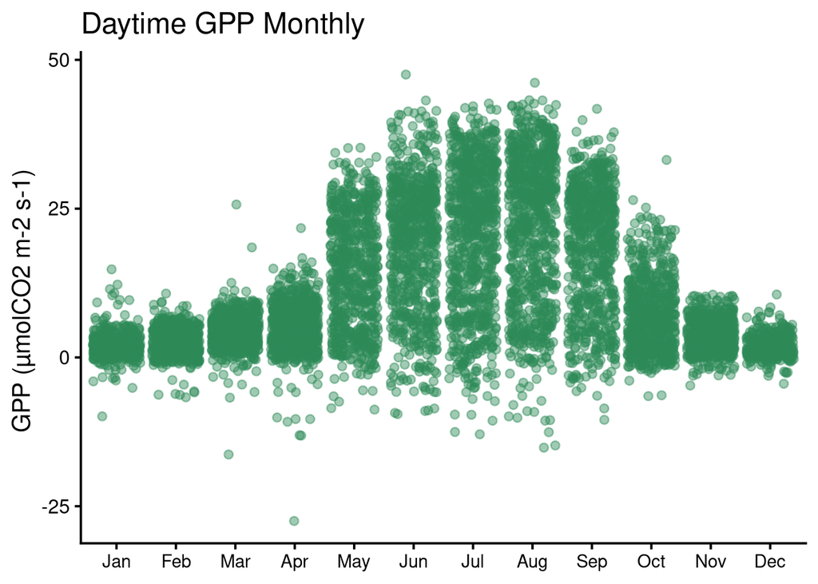

```r
# GOAL: visualize your response by your chosen grouping variable.

df_day %>%
  ggplot(aes(x = my_group, y = gpp)) +
  geom_jitter(alpha = 0.45, color = "seagreen") +
  theme_classic(base_size = 15) +
  theme(axis.text.x = element_text(size = 11)) +
  labs(
    x = NULL,
    y = "GPP (µmolCO2 m-2 s-1) ",
    title = "Daytime GPP Monthly"
  )
```

```r
# GOAL: summarize your response variable by your chosen grouping variable.
group_summary2 <- df_day %>%
  group_by(my_group) %>%
  summarise(
    mean_response = mean(gpp),
    sd_response = sd(gpp),
    n = n(),
  )

group_summary2
```

| my_group | mean_response | sd_response | n |
| --- | --- | --- | --- |
| Jan | 1.849245 | 2.114611 | 542 |
| Feb | 2.545832 | 2.420856 | 599 |
| Mar | 3.930059 | 2.853617 | 735 |
| Apr | 5.125394 | 4.097934 | 806 |
| May | 14.393315 | 9.387709 | 700 |
| Jun | 19.030501 | 10.794929 | 753 |
| Jul | 20.501564 | 11.976473 | 869 |
| Aug | 22.088039 | 12.232543 | 853 |
| Sep | 18.768084 | 10.211894 | 766 |
| Oct | 7.066484 | 6.141862 | 697 |

[output cut: 2 more lines]

```r
# GOAL: run a two-sample t-test for your chosen grouping variable.

anova_res <- aov(gpp ~ my_group, data = df_day)
summary(anova_res)
```

```
##               Df Sum Sq Mean Sq F value Pr(>F)
## my_group      11 512641   46604   715.4 <2e-16 ***
## Residuals   8275 539074      65
## ---
## Signif. codes:  0 '***' 0.001 '**' 0.01 '*' 0.05 '.' 0.1 ' ' 1
```

**Prompt (5–6 sentences):** Compare the day/night t-test to your second grouping-variable test.  
Which contrast was stronger? Which was more scientifically meaningful?  
Did the two tests produce similar or different conclusions?

> **I ran an ANOVA test instead because I have more than 2 categories to compare a monthly grouping variable with GPP** *Both the day/night t-test and the Daytime Monthly t-test had extremely low p-values, both being < 2.2E-16. I think this makes sense because statistically the GPP in the winter months was practically 0, even in the daytime, and the ANOVA test compared this 0 value to the much higher summer GPP monthly values of 20 or so. This high variability is very similar to the variability between day/night, being around 0 at night and around 10-20ss in the day. However, the day/night was more scientifically meaningful because there was less variability between the 2 groups, while the ANOVA test, comparing many groups, saw more variability. However, overall, the two test produced similar conclusions.*

## 21) Final reflection

Answer in **4–6 sentences**:

- How is a two-sample t-test similar to the one-mean hypothesis test from Part I?
- What changes when we move from “testing one mean” to “testing a difference in means”?
- How did the bootstrap group-mean plot help your understanding?

> *A two-sample t-test is similar to the one-mean hypothesis test because it is comparing variables to each other. However, when testing the comparison of just one mean, there is only one variable that has data variability (that being the sample). When doing a two-sample t-test, you are comparing two mean values with distinct variabilities, and quantifying how nearby those values are within a interval of 95% confidence, this tests the difference within means. The bootstrap group-mean plot helped this understanding by visualizing the separation between the density of yearly GPP amounts during strictly in the day, vs the density of yearly GPP amounts strictly at night. In this model, we see clearly the separation in averages caused by grouping by day/night, and that nighttime has a GPP of 0, while daytime is slightly broader with ranges of values in the 10s, showing higher GPP during the day.*

# Submission

- Knit your `.Rmd` to HTML.
- Commit and push both the `.Rmd` and knitted `.html` to your GitHub repo.
- Submit the GitHub repository link on Canvas.